# Object Oriented Methodologies:

Object Oriented Methodology (OOM) is a new system development approach encouraging and facilitating reuse of software components. With this methodology, a computer system can be developed on a component basis, which enables the effective reuse of existing components and facilitates the sharing of its components by other systems. By using OOM, higher productivity, lower maintenance cost and better quality can be achieved.

The basic steps of system designing using OOM may be listed as:

• System Analysis

• System Design

• Object Design

• Implementation

Some of the popular object oriented methodologies are listed below:

• Booch Methodology [1994]: He developed the Object Oriented Analysis and Object Oriented Design (OOA/OOD) concepts.

• RDD Methodology [1990]: Wirfs-Brock, Wilkerson, and Wiener developed Responsibility Driven Design (RDD) methodology.

• OMT methodology [1991]: James Rumbaugh led a team at research labs of General Electric to develop the Object Modeling Technique (OMT).

• OOSE [1994]: Ivar Jacobson developed the Object Oriented Software Engineering (OOSE).

OMT is an object-oriented software development methodology given by James Rumbaugh et.al. This methodology describes a method for analysis, design and implementation of a system using object-oriented technique. It is a fast, intuitive approach for identifying and modeling all the objects making a system. The OMT consists of three related but different viewpoints each capturing important aspects of the system i.e. the static, dynamic and functional behaviors of the system. These are described by object model, dynamic model and functional model of the OMT.

## Class and Object:

## Class:

A Class is a blueprint for an object. Objects and classes go hand in hand. We can't talk about one without talking about the other. And the entire point of Object-Oriented Design is not about objects, it's about classes, because we use classes to create objects.

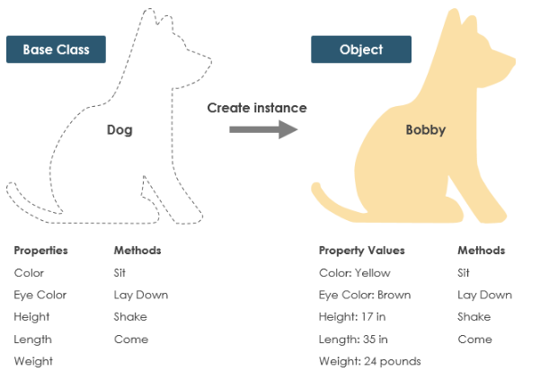

class describes a collection of similar objects. It is a template where certain basic characteristics of a set of objects are defined.Defining a class does not define any object, but it only creates a template. For objects to be actually created, instances of the class are to be created as per the requirement of the case.

In OMT, classes are represented by a rectangular box which may be divided into three parts as shown in Figure

The top part contains the name of the class written in bold, middle part contains a list of attributes and bottom part contains a list of operations.

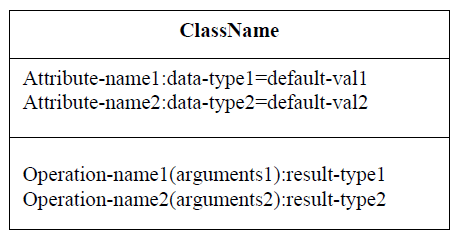

For example: Figure shows the class Book. Attributes of Book are title, author, publisher along with their data types. Operations on Book are open(), close(), read().

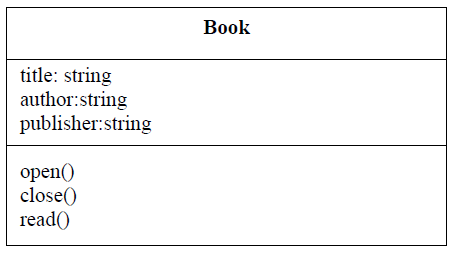

## Object:

object is an instance of an object class. Figure (rounded box) represents an object instance in OMT. Object instance is a particular object from an object class. The box may/may not be divided in particular regions.

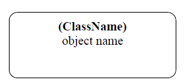

For example:

Three examples of objects of class Book shown in Figure (a), (b) & (c) respectively.

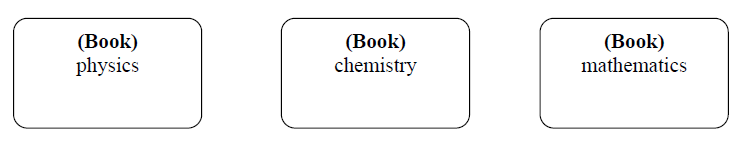

# Unified Modeling Language (UML) | Class Diagrams

UML is standardized in class diagrams. Since classes are the building block of an application that is based on OOPs, so as the class diagram has appropriate structure to represent the classes, inheritance, relationships, and everything that OOPs have in its context. It describes various kinds of objects and the static relationship in between them.

There are several points to be kept in focus while drawing the class diagram. These can be said as its syntax:

1.Each class is represented by a rectangle having a subdivision of three compartments name, attributes and operation.

2.There are three types of modifiers which are used to decide the visibility of attributes and operations.

- (+) is used for public visibility(for everyone)
- (#) is used for protected visibility (for friend and derived)
- (–) is used for private visibility (for only me)

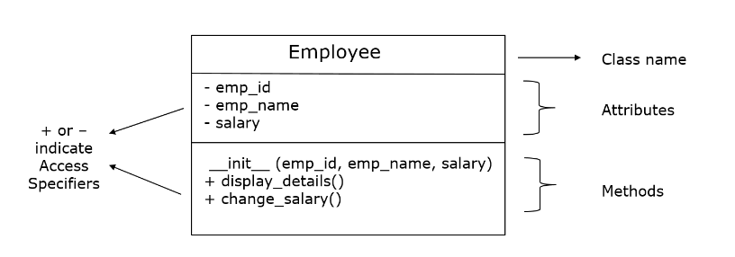

```python
class Employee:
    def __init__(self,id,name,salary):
        self.__emp_id=id
        self.__emp_name=name
        self.__salary=salary
    def display_details(self):
        print("id of Employee",self.__emp_id)
        print("name of Employee",self.__emp_name)
        print("salary of Employee",self.__salary)
    def change_salary(self,newsalary):
        self.__salary=newsalary
obj1=Employee(123,"rohan",50000)
obj1.display_details()
obj1.change_salary(60000)
obj1.display_details()
```

```
id of Employee 123
name of Employee rohan
salary of Employee 50000
id of Employee 123
name of Employee rohan
salary of Employee 60000
```